# lab3ran

-> The task is to predict disease progression in diabetic patientsbased on their BMI.

-> Objective is to develop a predictive model that predicts th disease progression.

```python
import numpy as np
import matplotlib.pyplot as plt
from sklearn import datasets, linear_model
from sklearn.metrics import mean_squared_error
import pandas as pd
from sklearn.model_selection import train_test_split
```

-> We load the diabetes dataset using scikit learn loader. This data contains both independent and the dependent avriable.

```python
diabetes_X, diabetes_y = datasets.load_diabetes(return_X_y=True)
# diabetes_X, diabetes_y = datasets.load_diabetes(return_X_y=True, as_frame=True)
diabetes_X = diabetes_X[:, np.newaxis, 2]
```

# Visualising the dataset

```python
diabetes_X
# diabetes_y
```

[output not shown]

[output cut: 387 more lines]

[output not shown]

```python
X_train, X_test, y_train, y_test = train_test_split(diabetes_X, diabetes_y, test_size=0.2, random_state=0)
```

```python
regr = linear_model.LinearRegression()
```

```python
regr.fit(X_train, y_train)
```

```
LinearRegression()
```

```python
y_test_pred = regr.predict(X_test)
y_train_pred = regr.predict(X_train)
```

```python
slope = regr.coef_[0]
intercept = regr.intercept_
```

```python
print(slope)
print(intercept)
```

```
981.6554361411928
152.28824927379569
```

```python
mse_train = mean_squared_error(y_train, y_train_pred)
mse_test = mean_squared_error(y_test, y_test_pred)
```

```python
print(mse_train)
print(mse_test)
```

```
3827.8186984113813
4150.6801893299835
```

# Training Data Graph

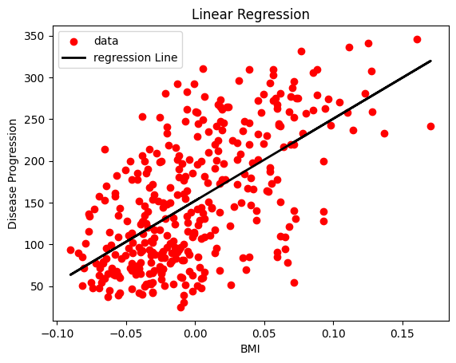

```python
plt.scatter(X_train, y_train, color='red', label='data')
plt.plot(X_train, y_train_pred, color='black', linewidth=2, label='regression Line')
plt.xlabel('BMI')
plt.ylabel('Disease Progression')
plt.title('Linear Regression')
plt.legend()
plt.show()
```

# Test Data Graph

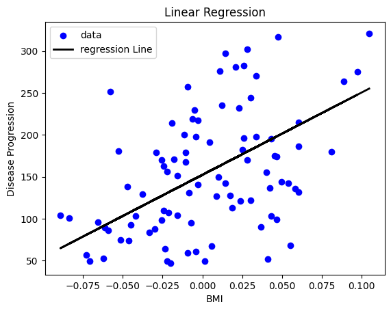

```python
plt.scatter(X_test, y_test, color='blue', label='data')
plt.plot(X_test, y_test_pred, color='black', linewidth=2, label='regression Line')
plt.xlabel('BMI')
plt.ylabel('Disease Progression')
plt.title('Linear Regression')
plt.legend()
plt.show()
```

# Report

-> Intercept : 152.28 -> Intercept is disease progression when the BMI is zero.

# Mean Squared Error

->MSE Train: Measures the average squared difference between the actual and predicted disease progression values on the training data. ->MSE Train : 3827.81

->MSE Test: Measures the same average squared difference between the actula and predicted disease progression but on the unseen test data. ->MSE Test : 4150.68

# Graphs

-> Training Data graph : The scatter plot shows a trend where disease progression increases with higher BMI.

-> Test Data graph : The test data plot shows a similar trend aswell.

-> The regression line shows a positive slope

# To say if its a good fit , it depends on the specific objectives and the context of the analysis.